# Getting started course tools

# Rstudio

Rstudio will be the primary data analysis and visualization software that you will use for the course

To install follow the instructions:

You will first need R https://cran.cnr.berkeley.edu/

Then R studio https://www.rstudio.com/products/rstudio/download/.

# Github and Rstudio

To link Rstudio and our version control software (Git), you need to first create a GitHub account at:

https://github.com/

Remember you user name and password - you will need thme

and then configure your computer to understand/interact with git, by downloading git software

https://git-scm.com/download/

and then finally link it with R studio

To do this: follow these instructions - get as far as creating a new project - for now leave the project empty; but make sure you create with a git repository

https://www.r-bloggers.com/rstudio-and-github/

When you get to the section on opening a shell, Rstudio may download additional software

If you are using a newer version of MacOS, you may also need to install X-quartz so that R can open graphics windows on the fly

https://www.xquartz.org/

You will need to re-start R

# Install Packages

load some libraries that are likely to be useful

```r
# Run this chunk only once in your Console
# Do not evaluate when knitting Rmarkdown

# list of packages
pkgs = c(
  'readr',        # read csv
  'readxl',       # read xls
  'dplyr',        # data frame manipulation
  'tidyr',        # data tidying
  'ggplot2')      # graphics package


# install packages if not found
for (p in pkgs){
  if (!require(p, character.only=T)){
    install.packages(p)

  }
}
```

# Programming in R

You have 3 options for writing R code

- directly type into the console (temporary)
- open an R script file (can be saved to git), useful for writing functions; next class!
- **add as a R module in an R Markdown file** (can be saved to git), helpful for documenting and presenting your work; I’m using an R Markdown file here

# Simple example

Now use the following R code to read that file in to R and do some basic analysis. Play with it a little and try different plots, aggregations, communting different variables.

You man need to set your working directory to the project directory

```r
# useful library for data clean up, manipulation, formating
library(dplyr)
# reading in text data; there are many other functions #that can be used to read other data types
clim = read.table("data/clim.txt", sep=",", header=T)

# clim is now a data frame; one of the most commonly used object types in R; it is like a matrix but can have a mixture of different data types
# see what columns are, look at first few lines
head(clim)
```

```
##       date       tmin       tmax   rain year month day   wy
## 1 01/01/42 -14.444444 -5.0000000 20.828 1942     1   1 1942
## 2 01/02/42 -14.444444 -0.5555556  0.000 1942     1   2 1942
## 3 01/03/42 -10.000000 -1.1111111  0.000 1942     1   3 1942
## 4 01/04/42 -10.000000  0.5555556  0.000 1942     1   4 1942
## 5 01/05/42  -9.444444  2.2222222  0.000 1942     1   5 1942
## 6 01/06/42  -7.777778  3.8888889  0.000 1942     1   6 1942
```

```r
# or just the names
names(clim)
```

```
## [1] "date"  "tmin"  "tmax"  "rain"  "year"  "month" "day"   "wy"
```

```r
# or add to a new window (need dplyr library for this)
View(clim)


# to access a particular column use $ or column number

head(clim$tmax)
```

```
## [1] -5.0000000 -0.5555556 -1.1111111  0.5555556  2.2222222  3.8888889
```

```r
# to get a particular column and row, i.e rainfall on 5th day
clim$rain[5]
```

```
## [1] 0
```

```r
#or everything on the 10th day
clim[10,]
```

```
##        date      tmin     tmax rain year month day   wy
## 10 01/10/42 -1.666667 12.77778    0 1942     1  10 1942
```

```r
#first 5 rows of several columns
clim[1:5, c("tmax","tmin","month")]
```

```
##         tmax       tmin month
## 1 -5.0000000 -14.444444     1
## 2 -0.5555556 -14.444444     1
## 3 -1.1111111 -10.000000     1
## 4  0.5555556 -10.000000     1
## 5  2.2222222  -9.444444     1
```

```r
# the 'c' denotes a vector in R
city = c("Jerusalem","Tel Aviv","Tsfat")
estheight = c(500,10,1000)

# you can combine vectors into a data frame
siteinfo = as.data.frame(cbind(city,estheight))
siteinfo
```

```
##        city estheight
## 1 Jerusalem       500
## 2  Tel Aviv        10
## 3     Tsfat      1000
```

```r
# you can subset
tmp = subset(clim, clim$day==20 & clim$month==2
             & clim$year < 1950)
tmp
```

```
##          date        tmin       tmax  rain year month day   wy
## 51   02/20/42  -6.6666667  5.5555556 0.000 1942     2  20 1942
## 416  02/20/43   0.5555556 14.4444444 0.000 1943     2  20 1943
## 781  02/20/44  -7.7777778  0.5555556 4.572 1944     2  20 1944
## 1147 02/20/45 -11.1111111  1.6666667 0.000 1945     2  20 1945
## 1512 02/20/46  -1.1111111  5.5555556 0.000 1946     2  20 1946
## 1877 02/20/47  -0.5555556  7.7777778 0.000 1947     2  20 1947
## 2242 02/20/48  -5.5555556 11.1111111 0.000 1948     2  20 1948
## 2608 02/20/49  -5.0000000  7.2222222 0.000 1949     2  20 1949
```

```r
# generate R understandable dates
clim$date = as.Date(paste(clim$day, clim$month, clim$year, sep="/"),"%d/%m/%Y")

# look at the file
View(clim)
# see some summary statistics of the columns
summary(clim)
```

```
##       date                 tmin              tmax
##  Min.   :1942-01-01   Min.   :-21.111   Min.   :-15.556
##  1st Qu.:1960-09-01   1st Qu.: -2.222   1st Qu.:  7.222
##  Median :1979-05-03   Median :  1.667   Median : 13.889
##  Mean   :1979-05-03   Mean   :  2.210   Mean   : 13.922
##  3rd Qu.:1998-01-01   3rd Qu.:  7.222   3rd Qu.: 21.111
##  Max.   :2016-09-02   Max.   : 26.111   Max.   : 32.778
##       rain              year          month             day
##  Min.   :  0.000   Min.   :1942   Min.   : 1.000   Min.   : 1.00
##  1st Qu.:  0.000   1st Qu.:1960   1st Qu.: 4.000   1st Qu.: 8.00
##  Median :  0.000   Median :1979   Median : 7.000   Median :16.00
##  Mean   :  2.829   Mean   :1979   Mean   : 6.505   Mean   :15.73
##  3rd Qu.:  0.000   3rd Qu.:1998   3rd Qu.: 9.000   3rd Qu.:23.00
##  Max.   :256.286   Max.   :2016   Max.   :12.000   Max.   :31.00
##        wy
##  Min.   :1942
##  1st Qu.:1960
##  Median :1979
##  Mean   :1979
##  3rd Qu.:1998
##  Max.   :2016
```

```r
# create a new table that summarizes by wateryear, use mean for state variables, and sum for flux variables
# this uses functions from the dplyr package
a = clim %>% select(wy,month,tmax, tmin) %>% group_by(wy, month) %>%
    summarize_each(funs(mean))

b = clim %>% select(wy,month,rain) %>% group_by(wy, month) %>%
    summarize_each(funs(sum))

# link data sets together (automatically uses shared colums)
clim.mwy = inner_join(a,b)
head(clim.mwy)
```

```
## Source: local data frame [6 x 5]
## Groups: wy [1]
##
##      wy month      tmax      tmin    rain
##   <int> <int>     <dbl>     <dbl>   <dbl>
## 1  1942     1  6.487455 -4.946237 118.110
## 2  1942     2  3.293651 -8.392857 152.908
## 3  1942     3  7.491039 -5.860215 126.492
## 4  1942     4  9.240741 -3.129630 217.932
## 5  1942     5 12.939068 -1.218638  55.626
## 6  1942     6 20.771048  5.678605   0.000
```

```r
#add a new variable
clim$tavg = (clim$tmin+clim$tmax)/2
range(clim$tavg)
```

```
## [1] -15.27778  25.27778
```

```r
range(clim$tmin)
```

```
## [1] -21.11111  26.11111
```

```r
range(clim$tmax)
```

```
## [1] -15.55556  32.77778
```

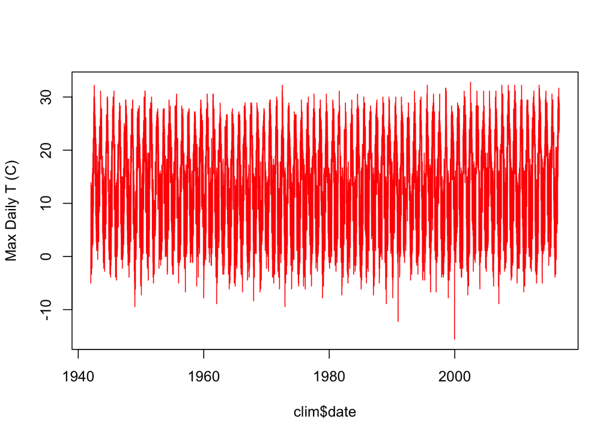

```r
plot(clim$date, clim$tmax, type="l", col="red", ylab="Max Daily T (C)")
```

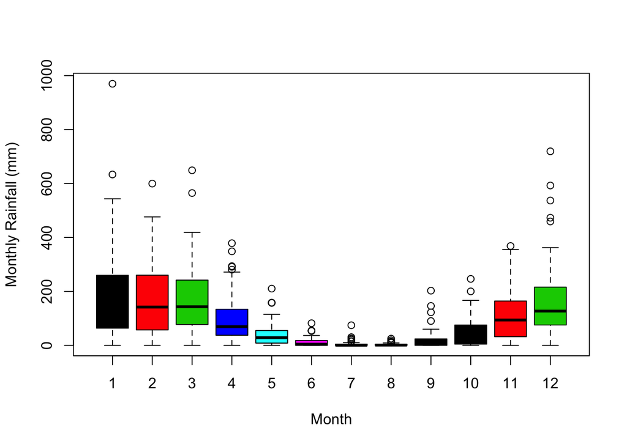

```r
boxplot(clim.mwy$rain~clim.mwy$month, ylab="Monthly Rainfall (mm)",
        xlab="Month", col=clim.mwy$month)
```

# Git - how to use version control with your project

R studio links nicely with git; you can use git to track changes both locally and in the remote repository

Lets start by assuming you’ve set up the project as described above

## Tracking things locally with git

- Check on the file you want to stage
- Commit
  - This will create your master branch
- Make a change to a file
- Use diff to see what changed
  - you must save the file first
- Commit changes
- Use history to see how things have changed
- Repeat as you change things

## Saving to your global github (for sharing)

- Make sure you have committed all recent changes
- get the http **address** from your github repo
- Open a shell in Git tab in Rstudio

type

*git remote add origin* **address**

*git push -u origin master*

- Notice how now under the Git tab you have colored arrows, you can now use these to push and pull from github to your local repo
- now make a local change and use these to update your github repo
- look at your repo online to see what you’ve done
- notice how now in git commit it will also track your branch in comparison with remote repo
- if you want other people to be able to make changes to your repo, add them as collaborators on the github website for that repo, under settings (see option on left side)

# Using existing (other people) repositories

Find the repository on Github and get its link: Clone with Https:

The link for my repository is https://github.com/naomitague/HebrewU.git

Start R studio again and create a new project

- chose the option ‘create from Git repository’
- use link you found on git site
- make sure you put this in a new directory so files don’t conflict with other projects